# transitiontrees — A Tutorial Walkthrough

Variable-order pathway modelling on student-engagement trajectories

transitiontrees

2026-06-07

# Why transitiontrees

Real trajectories — student engagement weeks, patient pathways, clickstreams, play sequences — usually have memory that *varies by context*. Some states predict the next state on their own; others only when paired with a longer history. Fixed-order Markov chains model “memory length 1, always” or “memory length 2, always”. **Variable-order context trees** let the data tell you, *for each context*, how much history matters.

`transitiontrees` is the modern variable-order Markov / prediction-suffix-tree toolkit for R. It ships the full **fit → prune → tune → score → bootstrap → compare → simulate** pipeline. This tutorial walks the whole surface on a real dataset.

# 1. The data

138 students, 15 weekly engagement states (Active / Average / Disengaged); trailing NAs mark dropouts.

```r
dim(trajectories)
```

```
## [1] 138  15
```

```r
table(unlist(trajectories), useNA = "ifany")
```

```
##
##     Active    Average Disengaged       <NA>
##        703        813        354        200
```

```r
head(trajectories[, 1:8])
```

```
##      1         2            3            4            5            6
## [1,] "Active"  "Disengaged" "Disengaged" "Disengaged" "Active"     "Active"
## [2,] "Average" "Average"    "Average"    "Average"    "Average"    "Average"
## [3,] "Average" "Active"     "Active"     "Active"     "Active"     "Active"
## [4,] "Active"  "Active"     "Active"     "Active"     "Active"     "Average"
## [5,] "Active"  "Active"     "Active"     "Average"    "Active"     "Average"
## [6,] "Average" "Average"    "Disengaged" "Average"    "Disengaged" "Disengaged"
##      7         8
## [1,] "Active"  "Active"
## [2,] "Average" "Average"
## [3,] "Active"  "Active"
## [4,] "Average" "Active"
## [5,] "Active"  "Active"
## [6,] "Average" "Average"
```

# 2. Fitting a pathway tree

The **pathway tree** is a variable-depth context tree. Each node is a pathway (sequence of recent states) and carries a smoothed conditional distribution over the next state.

```r
tree <- context_tree(
  trajectories,
  max_depth = 4L,    # longest pathway considered
  min_count      = 5L,    # min count for a context to get its own node
  smoothing = "floor"   # default; ymin = 0.001 used internally
)
tree
```

```
## <transitiontrees>  82 nodes, depth <= 4, 3 states  [unpruned]
##   alphabet : Active, Average, Disengaged
##   fit on   : 136 sequences, 1870 observations
##   smoothing: floor(ymin=0.001, rule=interpolate)   min_count = 5
## (start)   n=1870   -> Average (0.43)
## |-- Active    n=658    -> Active (0.70)
## |   |-- Active    n=433    -> Active (0.79)
## |   |   |-- Active    n=316    -> Active (0.84)
## |   |   |   |-- Active    n=240    -> Active (0.87)
## |   |   |   |-- Average   n=37     -> Active (0.59)
## |   |   |   `-- Disengaged  n=10     -> Active (0.90)
## |   |   |-- Average   n=70     -> Active (0.53)
## |   |   |   |-- Active    n=22     -> Active (0.55)
## |   |   |   `-- Average   n=37     -> Active (0.49)
## |   |   `-- Disengaged  n=15     -> Active (0.67)
## |   |       |-- Active    n=5      -> Active (1.00)
## |   |       `-- Average   n=7      -> Average (0.57)
## |   |-- Average   n=144    -> Active (0.50)
## |   |   |-- Active    n=53     -> Average (0.55)
## |   |   |   |-- Active    n=25     -> Average (0.52)
## |   |   |   `-- Average   n=26     -> Average (0.58)
## |   |   |-- Average   n=66     -> Active (0.58)
## |   |   |   |-- Active    n=23     -> Active (0.65)
## |   |   |   |-- Average   n=33     -> Average (0.48)
## |   |   |   `-- Disengaged  n=9      -> Active (0.78)
## |   |   `-- Disengaged  n=12     -> Average (0.83)
## |   |       `-- Average   n=5      -> Average (0.60)
## |   `-- Disengaged  n=29     -> Active (0.52)
## |       |-- Active    n=6      -> Active (0.83)
## |       |-- Average   n=13     -> Active (0.54)
## ... 56 more nodes (use as.data.frame(x) or summary(x))
```

`summary()` prints a banner with a truncated overview of the per-node table.

```r
summary(tree)
```

```
## <transitiontrees summary>  82 nodes, depth <= 4, 3 states  [unpruned]
##
##                   pathway depth count likely_next next_probability divergence
##                   (start)     0  1870     Average        0.4347594         NA
##                   Average     1   751     Average        0.6098535 0.11356246
##                    Active     1   658      Active        0.6975684 0.34948716
##                Disengaged     1   325  Disengaged        0.4830769 0.40306556
##          Active -> Active     2   433      Active        0.7852194 0.02860157
##        Average -> Average     2   419     Average        0.6778043 0.01466796
##         Active -> Average     2   160     Average        0.5187500 0.12282588
##         Average -> Active     2   144      Active        0.5000000 0.14727560
##  Disengaged -> Disengaged     2   139  Disengaged        0.6762590 0.10977363
##     Average -> Disengaged     2   134     Average        0.5000000 0.04611817
##  changes_prediction
##                  NA
##               FALSE
##                TRUE
##                TRUE
##               FALSE
##               FALSE
##               FALSE
##               FALSE
##               FALSE
##                TRUE
## # ... 72 more rows (use as.data.frame(tree) for the full table)
```

For the full tidy data.frame use `as.data.frame(tree)` (= `pathways(tree)`). Section 4 uses it heavily.

# 3. Pruning

Prune nodes that don’t earn their depth under a likelihood-ratio test against the (k-1)-suffix.

```r
pruned <- prune_tree(tree, criterion = "G2", alpha = 0.05)
pruned
```

```
## <transitiontrees>  25 nodes, depth <= 4, 3 states  [pruned]
##   alphabet : Active, Average, Disengaged
##   fit on   : 136 sequences, 1870 observations
##   smoothing: floor(ymin=0.001, rule=interpolate)   min_count = 5
##   pruned by: G2   alpha = 0.05
## (start)   n=1870   -> Average (0.43)
## |-- Active    n=658    -> Active (0.70)
## |   |-- Active    n=433    -> Active (0.79)
## |   |   |-- Active    n=316    -> Active (0.84)
## |   |   |   `-- Average   n=37     -> Active (0.59)
## |   |   `-- Average   n=70     -> Active (0.53)
## |   `-- Average   n=144    -> Active (0.50)
## |       `-- Disengaged  n=12     -> Average (0.83)
## |-- Average   n=751    -> Average (0.61)
## |   |-- Active    n=160    -> Average (0.52)
## |   |   `-- Disengaged  n=10     -> Average (0.50)
## |   |-- Average   n=419    -> Average (0.68)
## |   |   |-- Active    n=80     -> Average (0.57)
## |   |   `-- Average   n=248    -> Average (0.72)
## |   |       `-- Disengaged  n=37     -> Average (0.70)
## |   `-- Disengaged  n=122    -> Average (0.52)
## |       `-- Disengaged  n=31     -> Average (0.71)
## `-- Disengaged  n=325    -> Disengaged (0.48)
##     |-- Active    n=23     -> Active (0.39)
##     |-- Average   n=134    -> Average (0.50)
##     |   |-- Active    n=17     -> Active (0.41)
##     |   `-- Average   n=62     -> Average (0.52)
##     |       |-- Average   n=32     -> Average (0.75)
##     |       `-- Disengaged  n=13     -> Disengaged (0.85)
##     `-- Disengaged  n=139    -> Disengaged (0.68)
```

The pruned tree is the analysis object for several sections below.

# 4. The pathway-centric API

This is the consumer-facing view. Each row is a pathway with its count, modal next state, sharpness (`prob_next`), KL vs. its shorter-history parent, and a flag for whether the modal next state *flips* between the long and short history.

```r
common_pathways(pruned, top = 8)
```

|  | pathway | depth | count | likely_next | next_probability | divergence | changes_prediction |
| --- | --- | --- | --- | --- | --- | --- | --- |
| 1 | (start) | 0 | 1870 | Average | 0.4347594 | NA | NA |
| 2 | Average | 1 | 751 | Average | 0.6098535 | 0.113562458 | FALSE |
| 3 | Active | 1 | 658 | Active | 0.6975684 | 0.349487162 | TRUE |
| 4 | Active -> Active | 2 | 433 | Active | 0.7852194 | 0.028601567 | FALSE |
| 5 | Average -> Average | 2 | 419 | Average | 0.6778043 | 0.014667961 | FALSE |
| 6 | Disengaged | 1 | 325 | Disengaged | 0.4830769 | 0.403065556 | TRUE |
| 7 | Active -> Active -> Active | 3 | 316 | Active | 0.8354430 | 0.011491875 | FALSE |
| 8 | Average -> Average -> Average | 3 | 248 | Average | 0.7177419 | 0.006242261 | FALSE |

```r
divergent_pathways(pruned, top = 6)
```

|  | pathway | depth | count | likely_next | next_probability | divergence | changes_prediction |
| --- | --- | --- | --- | --- | --- | --- | --- |
| 1 | Disengaged -> Average -> Average -> Disengaged | 4 | 13 | Disengaged | 0.8461538 | 0.6883259 | TRUE |
| 2 | Disengaged -> Active -> Average | 3 | 10 | Average | 0.5000000 | 0.5477701 | FALSE |
| 3 | Disengaged | 1 | 325 | Disengaged | 0.4830769 | 0.4030656 | TRUE |
| 4 | Disengaged -> Average -> Active | 3 | 12 | Average | 0.8318333 | 0.3933342 | TRUE |
| 5 | Active | 1 | 658 | Active | 0.6975684 | 0.3494872 | TRUE |
| 6 | Active -> Disengaged | 2 | 23 | Active | 0.3913043 | 0.3478095 | TRUE |

```r
sharp_pathways(pruned, top = 5)
```

|  | pathway | depth | count | likely_next | next_probability | divergence | changes_prediction |
| --- | --- | --- | --- | --- | --- | --- | --- |
| 1 | Disengaged -> Average -> Average -> Disengaged | 4 | 13 | Disengaged | 0.8461538 | 0.68832595 | TRUE |
| 2 | Active -> Active -> Active | 3 | 316 | Active | 0.8354430 | 0.01149187 | FALSE |
| 3 | Disengaged -> Average -> Active | 3 | 12 | Average | 0.8318333 | 0.39333418 | TRUE |
| 4 | Active -> Active | 2 | 433 | Active | 0.7852194 | 0.02860157 | FALSE |
| 5 | Average -> Average -> Average -> Disengaged | 4 | 32 | Average | 0.7500000 | 0.21102640 | FALSE |

```r
divergent_pathways(pruned, flips_only = TRUE, top = 8)
```

|  | pathway | depth | count | likely_next | next_probability | divergence | changes_prediction |
| --- | --- | --- | --- | --- | --- | --- | --- |
| 1 | Disengaged -> Average -> Average -> Disengaged | 4 | 13 | Disengaged | 0.8461538 | 0.68832595 | TRUE |
| 3 | Disengaged | 1 | 325 | Disengaged | 0.4830769 | 0.40306556 | TRUE |
| 4 | Disengaged -> Average -> Active | 3 | 12 | Average | 0.8318333 | 0.39333418 | TRUE |
| 5 | Active | 1 | 658 | Active | 0.6975684 | 0.34948716 | TRUE |
| 6 | Active -> Disengaged | 2 | 23 | Active | 0.3913043 | 0.34780951 | TRUE |
| 7 | Active -> Average -> Disengaged | 3 | 17 | Active | 0.4117647 | 0.31329586 | TRUE |
| 19 | Average -> Disengaged | 2 | 134 | Average | 0.5000000 | 0.04611817 | TRUE |

The `path_dependence()` table is the per-context KL diagnostic in full — what the pruning rule was actually computing.

```r
head(tree_dependence(pruned), 12)
```

|  | pathway | depth | count | divergence | entropy | entropy_before | entropy_drop | likely_next | likely_before | changes_prediction |
| --- | --- | --- | --- | --- | --- | --- | --- | --- | --- | --- |
| 1 | Disengaged -> Average -> Average -> Disengaged | 4 | 13 | 0.6883259 | 0.7732283 | 1.3137762 | 0.540547878 | Disengaged | Average | TRUE |
| 2 | Disengaged -> Active -> Average | 3 | 10 | 0.5477701 | 1.3609640 | 1.3654995 | 0.004535442 | Average | Average | FALSE |
| 3 | Disengaged | 1 | 325 | 0.4030656 | 1.4032668 | 1.5076285 | 0.104361741 | Disengaged | Average | TRUE |
| 4 | Disengaged -> Average -> Active | 3 | 12 | 0.3933342 | 0.6623258 | 1.1249411 | 0.462615346 | Average | Active | TRUE |
| 5 | Active | 1 | 658 | 0.3494872 | 1.0404534 | 1.5076285 | 0.467175189 | Active | Average | TRUE |
| 6 | Active -> Disengaged | 2 | 23 | 0.3478095 | 1.5743318 | 1.4032668 | -0.171064986 | Active | Disengaged | TRUE |
| 7 | Active -> Average -> Disengaged | 3 | 17 | 0.3132959 | 1.5485652 | 1.4301429 | -0.118422293 | Active | Average | TRUE |
| 8 | Disengaged -> Average -> Average -> Average | 4 | 37 | 0.2659038 | 0.8889943 | 1.1401022 | 0.251107892 | Average | Average | FALSE |
| 9 | Average -> Active -> Active -> Active | 4 | 37 | 0.2388577 | 1.1172786 | 0.7202511 | -0.397027534 | Active | Active | FALSE |
| 10 | Average -> Active -> Active | 3 | 70 | 0.2330062 | 1.2048347 | 0.8490387 | -0.355796060 | Active | Active | FALSE |

[output cut: 2 more lines]

`plot_pathways()` and `plot_divergence()` give pathway-centric views that complement (rather than replace) the tree plot.

[figure not shown]

```r
plot_pathways(pruned, n = 12)
```

[figure not shown]

```r
plot_divergence(pruned, n = 12)
```

# 5. Predictive evaluation

`transitiontrees` plays nicely with the `stats` model-comparison toolchain. `logLik`, `AIC`, `BIC`, and a `perplexity()` metric all work out of the box.

```r
logLik(pruned)
```

```
## 'log Lik.' -1507.447 (df=50)
```

```r
AIC(pruned)
```

```
## [1] 3114.895
```

```r
BIC(pruned)
```

```
## [1] 3391.579
```

```r
perplexity(pruned)
```

```
## [1] 2.239207
```

A perplexity of ~2.24 on a 3-state alphabet says: *the model is as predictive as a uniform distribution over 2.24 outcomes*. The naïve baseline (fully uniform) is 3; perfect prediction is 1.

### 5.1 Holding out data

Held-out perplexity is the canonical prediction-suffix-tree evaluation metric. We split the 138 students into a 70 / 30 train-test partition.

```r
n <- nrow(trajectories)
test_idx  <- sample.int(n, size = round(0.3 * n))
train_idx <- setdiff(seq_len(n), test_idx)

tr_train <- context_tree(trajectories[train_idx, ],
                         max_depth = 4L, min_count = 5L)
tr_train <- prune_tree(tr_train, criterion = "G2", alpha = 0.05)

perplexity(tr_train, newdata = trajectories[test_idx, ])
```

```
## [1] 2.490618
```

Per-sequence and per-position scores:

```r
head(score_sequences(tr_train,
                     newdata = trajectories[test_idx, ]), 8)
```

|  | sequence_id | n_scored | log_lik | perplexity |
| --- | --- | --- | --- | --- |
| 1 | 1 | 15 | -14.248413 | 2.585436 |
| 2 | 2 | 15 | -19.175330 | 3.590729 |
| 3 | 3 | 15 | -14.565017 | 2.640587 |
| 4 | 4 | 15 | -23.417095 | 4.764248 |
| 5 | 5 | 15 | -11.821828 | 2.199262 |
| 6 | 6 | 15 | -20.477375 | 3.916343 |
| 7 | 7 | 15 | -14.248413 | 2.585436 |
| 8 | 8 | 15 | -8.573147 | 1.770998 |

```r
head(score_positions(tr_train,
                     newdata = trajectories[test_idx, ]), 8)
```

|  | sequence_id | position | matched_context | observed | predicted_prob | log_lik |
| --- | --- | --- | --- | --- | --- | --- |
| 1 | 1 | 1 | (start) | Disengaged | 0.18507235 | -1.687008431 |
| 2 | 1 | 2 | Disengaged | Average | 0.40358744 | -0.907362101 |
| 3 | 1 | 3 | Disengaged -> Average | Active | 0.05882353 | -2.833213344 |
| 4 | 1 | 4 | Disengaged -> Average -> Active | Average | 0.99800000 | -0.002002003 |
| 5 | 1 | 5 | Active -> Average | Average | 0.53982301 | -0.616513955 |
| 6 | 1 | 6 | Active -> Average -> Average | Average | 0.50000000 | -0.693147181 |
| 7 | 1 | 7 | Average -> Average -> Average | Disengaged | 0.15723270 | -1.850028377 |
| 8 | 1 | 8 | Average -> Average -> Average -> Disengaged | Average | 0.73913043 | -0.302280872 |

# 6. Smoothing schemes

Five smoothing schemes are implemented; `floor` is the default, the others interpolate with the parent’s smoothed distribution along the suffix path.

```r
methods <- c("floor", "laplace", "kneser_ney",
             "witten_bell", "jelinek_mercer")
res <- vapply(methods, function(m) {
  tr <- context_tree(trajectories[train_idx, ],
                     max_depth = 4L, min_count = 5L,
                     smoothing = m)
  perplexity(tr, newdata = trajectories[test_idx, ])
}, numeric(1))
data.frame(smoothing = methods,
           held_out_perplexity = round(res, 4))
```

|  | smoothing | held_out_perplexity |
| --- | --- | --- |
| floor | floor | 2.5786 |
| laplace | laplace | 2.3605 |
| kneser_ney | kneser_ney | 2.5391 |
| witten_bell | witten_bell | 2.4837 |
| jelinek_mercer | jelinek_mercer | 2.3292 |

Smoothing matters for held-out scoring. With a small alphabet and plenty of data, the differences are modest; on richer alphabets or shorter sequences the gap can be much larger.

`smooth_tree()` re-smooths a fitted tree without refitting:

```r
tr_kn <- smooth_tree(pruned,
                          list("kneser_ney", discount = 0.5))
perplexity(tr_kn)
```

```
## [1] 2.240073
```

# 7. Cross-validated tuning

`tune_tree()` runs k-fold CV at the **sequence level** over a grid of `(max_depth, nmin, smoothing, prune)` and returns a ranked data.frame with `attr(., "best")` pointing at the minimum-perplexity configuration.

```r
tg <- tune_tree(
  trajectories,
  max_depth = 1L:4L,
  min_count      = c(5L, 10L),
  smoothing = c("floor", "kneser_ney"),
  prune     = c(FALSE, TRUE),
  folds     = 5L,
  seed      = 42L
)
head(tg, 8)
```

|  | max_depth | nmin | smoothing | prune | logLik | n_scored | perplexity | n_nodes_avg |
| --- | --- | --- | --- | --- | --- | --- | --- | --- |
| 1 | 4 | 5 | kneser_ney(discount=0.75) | FALSE | -1565.146 | 1870 | 2.309374 | 76.4 |
| 2 | 4 | 10 | kneser_ney(discount=0.75) | FALSE | -1567.147 | 1870 | 2.311847 | 59.8 |
| 3 | 4 | 10 | floor(ymin=0.001, rule=interpolate) | FALSE | -1568.594 | 1870 | 2.313636 | 59.8 |
| 4 | 4 | 10 | kneser_ney(discount=0.75) | TRUE | -1572.389 | 1870 | 2.318336 | 23.4 |
| 5 | 4 | 5 | kneser_ney(discount=0.75) | TRUE | -1576.295 | 1870 | 2.323184 | 26.2 |
| 6 | 3 | 5 | kneser_ney(discount=0.75) | FALSE | -1578.600 | 1870 | 2.326049 | 37.6 |
| 7 | 3 | 10 | floor(ymin=0.001, rule=interpolate) | FALSE | -1578.793 | 1870 | 2.326290 | 31.2 |
| 8 | 4 | 10 | floor(ymin=0.001, rule=interpolate) | TRUE | -1580.100 | 1870 | 2.327916 | 23.4 |

```r
attr(tg, "best")
```

|  | max_depth | nmin | smoothing | prune | logLik | n_scored | perplexity | n_nodes_avg |
| --- | --- | --- | --- | --- | --- | --- | --- | --- |
| 1 | 4 | 5 | kneser_ney(discount=0.75) | FALSE | -1565.146 | 1870 | 2.309374 | 76.4 |

Built-in plot method:

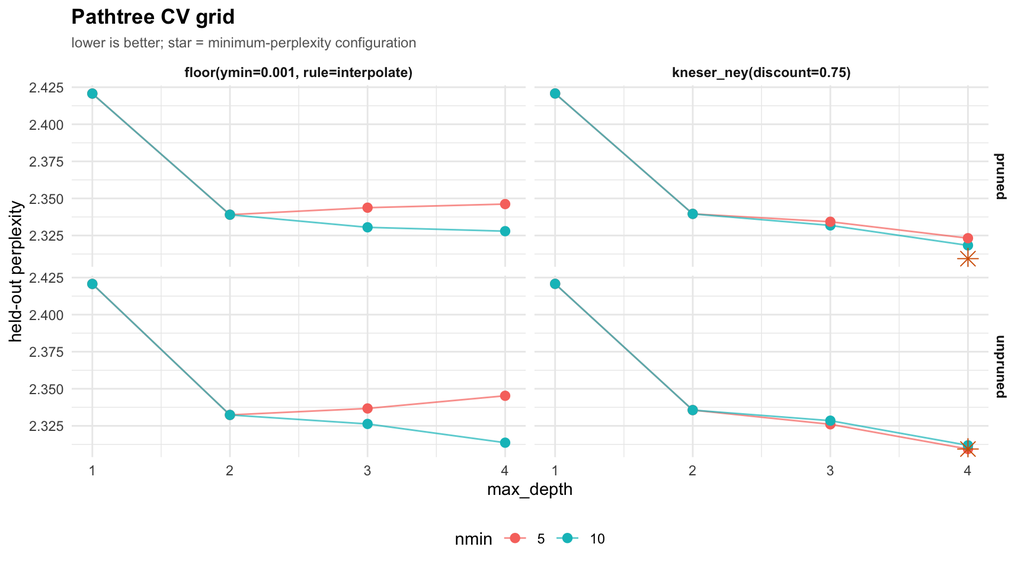

```r
plot(tg)
```

The chosen configuration is the model the CV procedure says will predict best on unseen students — refit at this configuration on the full data for downstream use.

# 8. Bootstrap pathway uncertainty

`prune()` answers “which pathways pass a parametric criterion *in this dataset?*” The bootstrap answers “which pathways *reproducibly* pass?” — a much stricter test.

`bootstrap_pathways()` is methodologically built on Saqr, Tikka & López-Pernas (2025) (doi:10.1145/3706468.3706513), extending an edge-level bootstrap framework to variable-depth pathways. It operates **only on raw counts** — no `nmin` filter, no smoothing inside the resampling loop, no extra parameters. Each iteration:

1. Resamples whole sequences with replacement.
2. Aggregates counts per depth from the precomputed per-sequence pair-index vectors.
3. Reads each original-tree pathway’s count vector and computes empirical statistics (count, modal-next, prob_next, KL vs empirical parent, G² LR statistic vs empirical parent, modal flip flag).

Two complementary measures are reported per pathway:

```r
boot <- bootstrap_pathways(tree, iter = 1000L, seed = 1L)
boot
```

```
## <transitiontrees_bootstrap>  1000 resamples
##   stability  : count in [0.50, 1.50] x observed, p < 0.05
##   informative: G^2 > qchisq(0.95, df=k-1) = 5.99, threshold 0.80
##   pathways   : 82 total, 56 stable, 16 informative, 15 both
##
## top pathways (stable + informative first):
##                                pathway depth count p_stability stability_rate
##                                Average     1   751       0.001          1.000
##                                 Active     1   658       0.001          1.000
##                       Active -> Active     2   433       0.001          1.000
##                             Disengaged     1   325       0.001          1.000
##                      Active -> Average     2   160       0.001          1.000
##                      Average -> Active     2   144       0.001          1.000
##                  Disengaged -> Average     2   122       0.001          1.000
##           Active -> Average -> Average     3    80       0.001          1.000
##            Average -> Active -> Active     3    70       0.001          1.000
##  Average -> Active -> Active -> Active     4    37       0.002          0.999
##  stable informative_rate informative mean_G2 ci_G2_lo ci_G2_hi
##    TRUE            1.000        TRUE 119.761   76.381  171.708
##    TRUE            1.000        TRUE 319.894  247.812  397.557
##    TRUE            0.994        TRUE  18.241    7.875   30.772
##    TRUE            1.000        TRUE 181.559  111.364  261.946
##    TRUE            0.997        TRUE  28.844   12.087   50.532
##    TRUE            1.000        TRUE  30.912   12.900   53.404
##    TRUE            1.000        TRUE  31.807   14.086   52.481
##    TRUE            0.858        TRUE  12.685    2.329   26.726
##    TRUE            0.995        TRUE  24.069    9.891   43.970
##    TRUE            0.844        TRUE  13.486    2.331   31.458
## # ... 72 more pathways (use summary(x) for full table)
```

The forest plot orders pathways by trustworthiness (stable + informative first), shows the bootstrap CI on G² against the chi-square critical value (dashed line), and colour-codes each pathway by category:

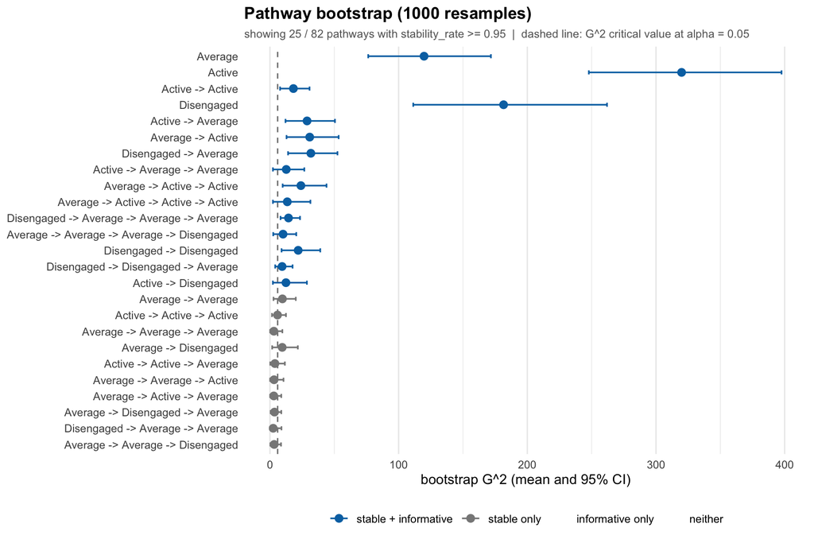

```r
plot(boot)
```

Raw bootstrap distribution of the chosen statistic per pathway:

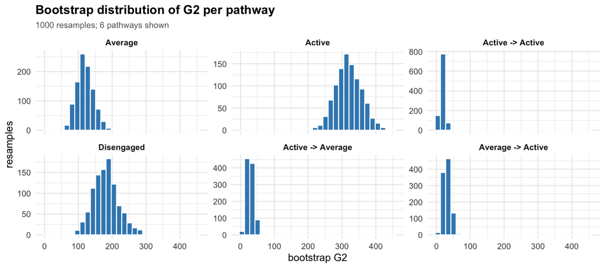

```r
plot_pathway_resamples(boot, stat = "G2", top = 6L)
```

The full per-pathway view:

```r
summary(boot)
```

| pathway | depth | count | likely_next | next_probability | divergence | changes_prediction | G2 | p_stability | stability_rate | stable | informative_rate | informative | flip_consistency | mean_count | sd_count | ci_count_lo | ci_count_hi | mean_next_probability | sd_next_probability | ci_next_probability_lo | ci_next_probability_hi | mean_divergence | sd_divergence | ci_divergence_lo | ci_divergence_hi | mean_G2 | sd_G2 | ci_G2_lo | ci_G2_hi |
| --- | --- | --- | --- | --- | --- | --- | --- | --- | --- | --- | --- | --- | --- | --- | --- | --- | --- | --- | --- | --- | --- | --- | --- | --- | --- | --- | --- | --- | --- |
| Average | 1 | 751 | Average | 0.6098535 | 0.113562458 | FALSE | 118.23067725 | 0.000999001 | 1.000 | TRUE | 1.000 | TRUE | 0.8840000 | 749.722 | 45.421513 | 655.000 | 837.000 | 0.6082431 | 0.02349755 | 0.5610849 | 0.6533295 | 0.115903150 | 0.026055226 | 7.164671e-02 | 0.17247742 | 119.760946 | 24.5231911 | 7.638114e+01 | 171.708185 |
| Active | 1 | 658 | Active | 0.6975684 | 0.349487162 | TRUE | 318.79579031 | 0.000999001 | 1.000 | TRUE | 1.000 | TRUE | 0.8840000 | 658.403 | 52.998617 | 556.000 | 769.000 | 0.6972174 | 0.02691379 | 0.6425091 | 0.7489768 | 0.352677759 | 0.050419251 | 2.597345e-01 | 0.45197136 | 319.893672 | 38.3605427 | 2.478122e+02 | 397.557433 |
| Active -> Active | 2 | 433 | Active | 0.7852194 | 0.028601567 | FALSE | 17.16853276 | 0.000999001 | 1.000 | TRUE | 0.994 | TRUE | 1.0000000 | 433.723 | 46.622762 | 347.000 | 527.000 | 0.7846050 | 0.02722982 | 0.7276705 | 0.8329812 | 0.030571311 | 0.010284308 | 1.334511e-02 | 0.05294506 | 18.241028 | 5.9654994 | 7.874566e+00 | 30.772337 |
| Disengaged | 1 | 325 | Disengaged | 0.4830769 | 0.403065556 | TRUE | 181.59943994 | 0.000999001 | 1.000 | TRUE | 1.000 | TRUE | 0.8290000 | 326.143 | 33.847484 | 264.000 | 398.000 | 0.4877278 | 0.03616325 | 0.4315754 | 0.5662703 | 0.401879229 | 0.074433729 | 2.588485e-01 | 0.56396087 | 181.559291 | 37.8007929 | 1.113641e+02 | 261.946369 |
| Active -> Average | 2 | 160 | Average | 0.5187500 | 0.122825881 | FALSE | 27.24365225 | 0.000999001 | 1.000 | TRUE | 0.997 | TRUE | 0.9560000 | 159.499 | 14.050958 | 133.000 | 187.000 | 0.5200763 | 0.03925704 | 0.4513889 | 0.6012910 | 0.131485910 | 0.047479722 | 5.362828e-02 | 0.23468814 | 28.844260 | 10.0072306 | 1.208666e+01 | 50.531511 |
| Average -> Active | 2 | 144 | Active | 0.5000000 | 0.147275598 | FALSE | 29.40009559 | 0.000999001 | 1.000 | TRUE | 1.000 | TRUE | 0.6110000 | 143.412 | 13.618727 | 117.000 | 171.025 | 0.5232941 | 0.02496616 | 0.4883579 | 0.5826786 | 0.157243713 | 0.056951547 | 6.226401e-02 | 0.27808302 | 30.912088 | 10.5867713 | 1.289992e+01 | 53.403548 |
| Disengaged -> Average | 2 | 122 | Average | 0.5163934 | 0.176186405 | FALSE | 29.79803876 | 0.000999001 | 1.000 | TRUE | 1.000 | TRUE | 0.9490000 | 122.853 | 13.136436 | 97.975 | 151.000 | 0.5151504 | 0.04131611 | 0.4454510 | 0.6040303 | 0.188386070 | 0.061546388 | 8.470918e-02 | 0.32753397 | 31.806736 | 9.9422358 | 1.408566e+01 | 52.481306 |
| Active -> Average -> Average | 3 | 80 | Average | 0.5750000 | 0.101876320 | FALSE | 11.29844543 | 0.000999001 | 1.000 | TRUE | 0.858 | TRUE | 0.9890000 | 79.630 | 8.658757 | 63.000 | 97.000 | 0.5780715 | 0.06438693 | 0.4533095 | 0.7000325 | 0.115781474 | 0.059801093 | 2.204874e-02 | 0.24965135 | 12.684877 | 6.4455692 | 2.329196e+00 | 26.725504 |
| Average -> Active -> Active | 3 | 70 | Active | 0.5285714 | 0.233006163 | FALSE | 22.61105910 | 0.000999001 | 1.000 | TRUE | 0.995 | TRUE | 0.8330000 | 69.741 | 8.306438 | 54.000 | 87.000 | 0.5377113 | 0.04313358 | 0.4729730 | 0.6291515 | 0.252772631 | 0.097227623 | 9.735459e-02 | 0.47645711 | 24.069089 | 8.6542072 | 9.891322e+00 | 43.970455 |
| Average -> Active -> Active -> Active | 4 | 37 | Active | 0.5945946 | 0.238857703 | FALSE | 12.25170224 | 0.001998002 | 0.999 | TRUE | 0.844 | TRUE | 0.9140000 | 36.765 | 5.850128 | 26.000 | 49.000 | 0.6092312 | 0.07794393 | 0.4864865 | 0.7692857 | 0.264741146 | 0.142033806 | 4.978474e-02 | 0.59444614 | 13.486477 | 7.4785231 | 2.330546e+00 | 31.458284 |

[output cut: 72 more lines]

### 8.1 Reading the trajectories result

[output not shown]

### 8.2 Why two flags?

The two measures answer different questions:

- `stable` asks *“is the count value reproducible under resampling?”* — the edge-level bootstrap framing. With enough data, counts reproduce regardless of whether the underlying structure is meaningful.
- `informative` asks *“does the LR test against parent reproducibly clear the chi-square threshold?”* — the test that distinguishes real signal from finite-sample noise.

A pathway worth interpreting is **both**. `stable` alone keeps high-count noise pathways; `informative` alone could surface low-count borderline pathways whose sample-level G² is high by chance. The conjunction screens both failure modes.

### 8.3 Monte Carlo calibration

To verify the test isn’t simply ratifying its own assumptions, we ran a Monte Carlo evaluation across 600 simulated datasets — 200 datasets each from three regimes:

| regime | transition matrix | what it tests |
| --- | --- | --- |
| STRONG | `P(modal) = 0.90` | high-power detection |
| WEAK | `P(modal) = 0.50` | moderate-effect detection |
| RANDOM | uniform `1/3` | Type-I rate |

For 1st-order Markov data, ground truth is unambiguous: depth-1 pathways are *truly informative* (their conditional differs from the marginal); depth-2+ pathways are *truly NOT informative* (under the Markov property, conditional on most recent state, prior history adds nothing); for RANDOM, no pathway is informative.

| regime | n | TP | FP | TN | FN | TPR | FPR | Precision | F1 |
| --- | --- | --- | --- | --- | --- | --- | --- | --- | --- |
| STRONG | 2400 | 600 | 0 | 1800 | 0 | **1.000** | 0.000 | 1.000 | 1.000 |
| WEAK | 2400 | 600 | 2 | 1798 | 0 | **1.000** | 0.001 | 0.997 | 0.998 |
| RANDOM | 2400 | 0 | 1 | 2399 | 0 | — | 0.000 | — | — |

# 9. Tree introspection

Three accessors expose the tree as a queryable object:

```r
# Full conditional distribution at a specific pathway
query_pathway(pruned, c("Active", "Active"))
```

```
##     Active    Average Disengaged
## 0.78521940 0.19399538 0.02078522
```

```r
# Single-cell lookup
query_pathway(pruned, "Disengaged", next_state = "Disengaged")
```

```
## [1] 0.4830769
```

```r
# Membership test
pathway_exists(pruned, "Active -> Disengaged")
```

```
## [1] TRUE
```

`subtree()` extracts a slice of the tree rooted at a given pathway:

```r
sub <- subtree(pruned, "Active")
sub
```

```
## <transitiontrees>  7 nodes, depth <= 4, 3 states  [pruned]
##   alphabet : Active, Average, Disengaged
##   fit on   : 136 sequences, 1870 observations
##   smoothing: floor(ymin=0.001, rule=interpolate)   min_count = 5
##   pruned by: G2   alpha = 0.05
##   subtree of: Active
```

```r
attr(sub, "local_root")
```

```
## [1] "Active"
```

# 10. Comparing two cohorts

The differentiating prediction-suffix-tree primitive: **the tree IS the comparison object**. To ask whether two student groups generate significantly different pathway dynamics, fit a tree on each and compare with a permutation test.

We split students by their early engagement (first 4 weeks) — a contrived stratification, but illustrative.

```r
early_active_count <- rowSums(trajectories[, 1:4] == "Active",
                               na.rm = TRUE)
group_a <- trajectories[early_active_count >= 3, ]
group_b <- trajectories[early_active_count <  3, ]
nrow(group_a); nrow(group_b)
```

```
## [1] 41
```

```
## [1] 97
```

```r
tr_a <- context_tree(group_a, max_depth = 3L, min_count = 5L)
tr_b <- context_tree(group_b, max_depth = 3L, min_count = 5L)

cmp <- compare_trees(tr_a, tr_b, iter = 100L, seed = 1L)
cmp
```

```
## <transitiontrees_comparison>  iter = 100
##   observed distance : 0.62
##   null mean         : 0.0392
##   p-value           : 0.0099
##
## top divergent pathways:
##                              pathway count_a count_b divergence_ab
##      Active -> Disengaged -> Average       0       7         3.416
##   Disengaged -> Disengaged -> Active       0       9         1.083
##  Disengaged -> Disengaged -> Average       0      30         3.242
##                 Disengaged -> Active       6      23         0.923
##       Active -> Disengaged -> Active       5       0         0.923
##       Disengaged -> Active -> Active       6       9         0.797
##  divergence_ba divergence_sym
##          1.585          2.501
##          3.669          2.376
##          1.008          2.125
##          3.220          2.072
##          3.220          2.072
##          2.874          1.835
```

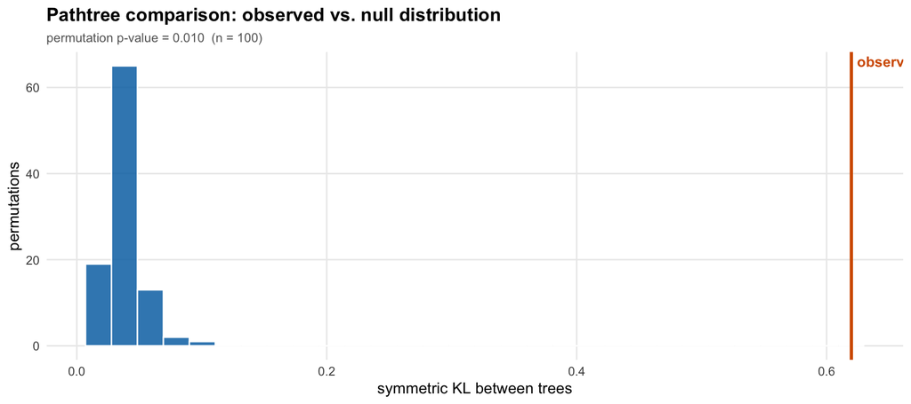

```r
plot(cmp)
```

`tree_distance()` is the bare scalar without the permutation test — useful for pairwise distance matrices over many cohorts.

```r
tree_distance(tr_a, tr_b)
```

```
## [1] 0.619837
```

# 11. Visualisation

Two ggplot-based plot styles, one dispatcher. No htmlwidget / JavaScript dependencies.

### 11.1 Dendrogram (default)

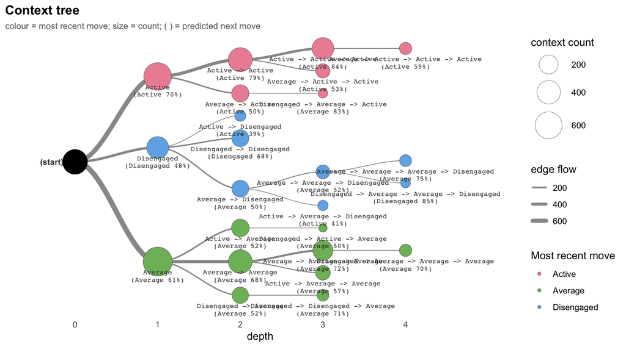

```r
plot(pruned)
```

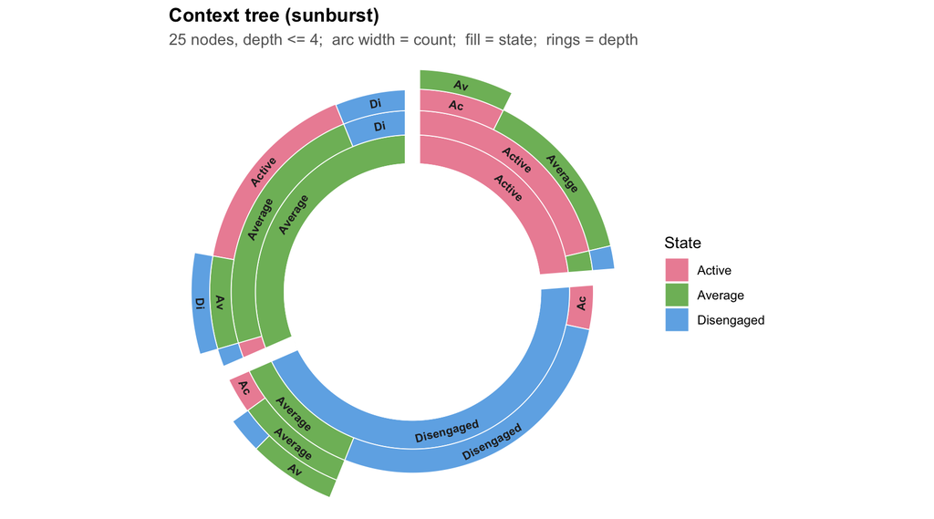

```r
plot(pruned, style = "icicle")
```

# 12. Generating new sequences

Every fitted tree is also a generative model: sample sequences from its conditional distributions.

```r
gen <- generate_sequences(pruned, n = 5, length = 12)
gen
```

```
##      [,1]         [,2]      [,3]         [,4]      [,5]         [,6]
## [1,] "Active"     "Active"  "Active"     "Active"  "Active"     "Disengaged"
## [2,] "Active"     "Active"  "Active"     "Active"  "Active"     "Active"
## [3,] "Active"     "Average" "Average"    "Active"  "Active"     "Average"
## [4,] "Disengaged" "Average" "Disengaged" "Average" "Disengaged" "Average"
## [5,] "Active"     "Average" "Average"    "Active"  "Average"    "Average"
##      [,7]         [,8]      [,9]      [,10]     [,11]        [,12]
## [1,] "Active"     "Active"  "Active"  "Active"  "Average"    "Average"
## [2,] "Active"     "Active"  "Active"  "Active"  "Active"     "Active"
## [3,] "Active"     "Active"  "Active"  "Active"  "Active"     "Disengaged"
## [4,] "Disengaged" "Average" "Average" "Average" "Average"    "Disengaged"
## [5,] "Active"     "Active"  "Active"  "Average" "Disengaged" "Disengaged"
```

# 13. `stslist` input, network objects + per-sequence weights

`context_tree()` accepts state-sequence (`stslist`) objects natively and honours their per-sequence weights. The bundled `engagement` dataset is an `stslist`, so it can be fed in directly:

```r
class(engagement)
```

```
## [1] "stslist"    "data.frame"
```

```r
tr_sts <- context_tree(engagement, max_depth = 2L)
tr_sts
```

```
## <transitiontrees>  17 nodes, depth <= 2, 4 states  [unpruned]
##   alphabet : %, Active, Average, Disengaged
##   fit on   : 1000 sequences, 25000 observations
##   smoothing: floor(ymin=0.001, rule=interpolate)   min_count = 5
## (start)   n=25000  -> Active (0.50)
## |-- %         n=145    -> % (1.00)
## |   |-- Active    n=88     -> % (1.00)
## |   |-- Average   n=15     -> % (1.00)
## |   `-- Disengaged  n=42     -> % (1.00)
## |-- Active    n=12063  -> Active (0.85)
## |   |-- Active    n=9915   -> Active (0.85)
## |   |-- Average   n=1490   -> Active (0.85)
## |   `-- Disengaged  n=315    -> Active (0.84)
## |-- Average   n=5118   -> Average (0.54)
## |   |-- Active    n=1044   -> Average (0.53)
## |   |-- Average   n=2699   -> Average (0.53)
## |   `-- Disengaged  n=1056   -> Average (0.56)
## `-- Disengaged  n=6674   -> Disengaged (0.78)
##     |-- Active    n=586    -> Disengaged (0.81)
##     |-- Average   n=723    -> Disengaged (0.73)
##     `-- Disengaged  n=5027   -> Disengaged (0.78)
```

`context_tree()` also accepts a fitted transition/network object directly, auto-detected by its S3 class — useful for slotting a pathway tree onto an already-estimated model:

```r
# transitiontrees also accepts a fitted transition/network object
# directly, auto-detected by its S3 class:
# context_tree(my_network_object, max_depth = 2L)
```

Per-sequence weights for the design-weighting case:

```r
w <- runif(nrow(trajectories), 0.5, 2)
tr_w <- context_tree(trajectories,
                     max_depth = 3L, min_count = 5L,
                     weights = w)
length(tr_w$nodes)
```

```
## [1] 38
```

# 14. Reference / equivalence

`transitiontrees` was validated to **machine precision** against an archived external reference implementation of the prediction-suffix tree (Gabadinho & Ritschard 2013) — counts exact, smoothed probabilities max abs error 1.11 × 10⁻¹⁶ across 30 random configurations. The default `smoothing = "floor"` path is byte-identical to that reference.

# Recap: the public surface

| Goal | Function |
| --- | --- |
| Fit | `context_tree()` |
| Prune | `prune()` |
| Pathway-centric inspection | `pathways()`, `common_pathways()`, `divergent_pathways()`, `sharp_pathways()`, `path_dependence()` |
| Score | `logLik()`, `AIC()`, `BIC()`, `perplexity()`, `score_sequences()`, `score_positions()` |
| Smooth | five schemes via `context_tree(smoothing = ...)`, `smooth_tree()` |
| Tune | `tune_tree()` |
| Bootstrap | `bootstrap_pathways()`, `plot_pathway_resamples()` |
| Query | `query_pathway()`, `subtree()`, `pathway_exists()` |
| Compare | `tree_distance()`, `compare_trees()` |
| Predict / Simulate | `predict()`, `generate_sequences()` |
| Visualise | `plot(style = c("dendrogram", "icicle"))`, `plot_pathways()`, `plot_divergence()` |

# References

- Begleiter, R., El-Yaniv, R., Yona, G. (2004). On prediction using variable-order Markov models. *JAIR*, **22**, 385–421.
- Bühlmann, P., Wyner, A. J. (1999). Variable length Markov chains. *Annals of Statistics*, **27**, 480–513.
- Gabadinho, A., Ritschard, G. (2013). Searching for typical life trajectories applied to childbirth histories. In: *Gendered Life Courses Between Standardization and Individualization*, 287–312.
- Phipson, B., Smyth, G. K. (2010). Permutation p-values should never be zero. *Statistical Applications in Genetics and Molecular Biology*, **9**(1), Article 39.
- Ron, D., Singer, Y., Tishby, N. (1996). The power of amnesia: learning probabilistic automata with variable memory length. *Machine Learning*, **25**, 117–149.
- **Saqr, M., Tikka, S., López-Pernas, S. (2025). Transition Network Analysis: a novel framework for modeling, visualizing, and identifying the temporal patterns of learners and learning processes.** *LAK ’25*, doi:10.1145/3706468.3706513. — The edge-level bootstrap framework that transitiontrees’s `bootstrap_pathways()` extends to variable-depth pathways.
- Willems, F. M. J., Shtarkov, Y. M., Tjalkens, T. J. (1995). The context-tree weighting method: basic properties. *IEEE Transactions on Information Theory*, **41**, 653–664.